# Introduction to Deep Learning - Week 4

## NLP Disaster Tweets Kaggle Mini Project

**Github Link** https://github.com/conditas/NLPDisasterTweet

This project uses Natural Language Processing and a Recurrent Neural Netwrok Model (RNN) for the Kaggle Competition "Natural Language Processing with Disaster Tweets." It involves being able to predict and classify whether twitter texts are about an actual disaster or not. This can be helpful for spreading real-time information during emergency situations.

### Import Libraries

The following libraries will be used in my project.

```python
%matplotlib inline
import warnings
warnings.simplefilter("ignore", FutureWarning)

import pandas as pd
import numpy as np
import scipy as sp
import scipy.stats as stats
import seaborn as sns
import matplotlib.pyplot as plt


import gc
import os

import sklearn
from sklearn.model_selection import train_test_split
from sklearn.metrics import roc_auc_score, accuracy_score,ConfusionMatrixDisplay,confusion_matrix, f1_score
from tensorflow.keras.preprocessing.text import Tokenizer

import tensorflow as tf
from tensorflow import keras
from keras import layers, optimizers
import keras_core as keras
import keras_nlp
from tensorflow.keras.models import Sequential
from tensorflow.keras.preprocessing.text import Tokenizer
from tensorflow.keras.layers import Embedding, LSTM, Bidirectional, Dense,GlobalMaxPool1D,BatchNormalization, Dropout
from tensorflow.keras.preprocessing.sequence import pad_sequences

os.environ['KERAS_BACKEND'] = 'tensorflow'
```

### Load the Data

The data comes from the "Natural Language Processing with Disaster Tweets" Kaggle competition. It consists of a two files a train.csv and a test.csv. The train file contains 5 columns and 7613 rows. The test file will be used for the kaggle competition submission and has 4 columns with 3263 rows. The table below summarizes the variables and below the table I print out the data types for each column.

| Variable | Description |
| --- | --- |
| id | unique identifier |
| keyword | keyword from tweet |
| location | where tweet was sent from |
| text | text of twitter tweet |
| target | classifier '1' for disaster and '0' for non-disaster |

**Data Citation**

Addison Howard, devrishi, Phil Culliton, and Yufeng Guo. Natural Language Processing with Disaster Tweets. https://kaggle.com/competitions/nlp-getting-started/data, 2019. Kaggle.

```python
df_train = pd.read_csv("train.csv")
df_test = pd.read_csv("test.csv")

print('Training:\n')
print('Shape = {}'.format(df_train.shape))
print(df_train.dtypes)

print('\nTest:\n')
print('Shape = {}'.format(df_test.shape))
print(df_test.dtypes)

print("Example of Data:\n", df_train.head(5))
```

```
Training:

Shape = (7613, 5)
id           int64
keyword     object
location    object
text        object
target       int64
dtype: object

Test:

Shape = (3263, 4)
id           int64
keyword     object
location    object
text        object
dtype: object
Example of Data:
    id keyword location                                               text  \
0   1     NaN      NaN  Our Deeds are the Reason of this #earthquake M...
1   4     NaN      NaN             Forest fire near La Ronge Sask. Canada
2   5     NaN      NaN  All residents asked to 'shelter in place' are ...
3   6     NaN      NaN  13,000 people receive #wildfires evacuation or...
4   7     NaN      NaN  Just got sent this photo from Ruby #Alaska as ...

   target
0       1
1       1
2       1
3       1
4       1
```

### Exploratory Data Analysis

In my exploratory data analysis I compare the number of disaster tweets vs non-disaster tweets and calculate an imbalance ratio. This ratio was 1.35 which should be fine for modeling. I check for null values accross the columns. There were not any null or empty values in the text column. The distribution of locations shows most of the tweets came from the US. There were some descrepencies on the naming (USA vs United Staes) and the location column had a significant number of missing values (33%) so I will not be using this information. I compare text lengths of disaster vs non-disaster tweets. In general, the disaster tweets tend to be longer than non-disaster.

Finally I split the training data set 80/20 in order to train and validate models.

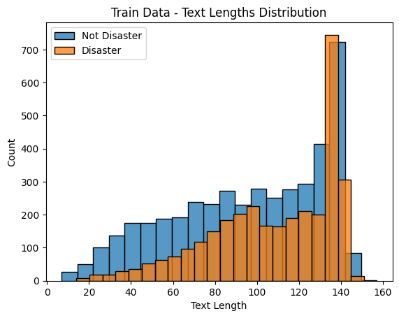

```
Examples of Disaster Tweets
0    Our Deeds are the Reason of this #earthquake M...
1               Forest fire near La Ronge Sask. Canada
2    All residents asked to 'shelter in place' are ...
3    13,000 people receive #wildfires evacuation or...
4    Just got sent this photo from Ruby #Alaska as ...
5    #RockyFire Update => California Hwy. 20 closed...
6    #flood #disaster Heavy rain causes flash flood...
7    I'm on top of the hill and I can see a fire in...
8    There's an emergency evacuation happening now ...
9    I'm afraid that the tornado is coming to our a...
Name: text, dtype: object

Examples of Non-Disaster Tweets
15                  What's up man?
16                   I love fruits
17                Summer is lovely
18               My car is so fast
19    What a goooooooaaaaaal!!!!!!
20          this is ridiculous....
21               London is cool ;)
22                     Love skiing
23           What a wonderful day!
24                        LOOOOOOL
Name: text, dtype: object
train dimensions:  (7613, 5)
test dimensions:  (3263, 4)

Train Dataset

Null values in text?:  0

Null values in keyword?:  61

Null values in location?:  2533


Test Dataset

Null values in text?:  0

Null values in keyword?:  26

Null values in location?:  1105
```

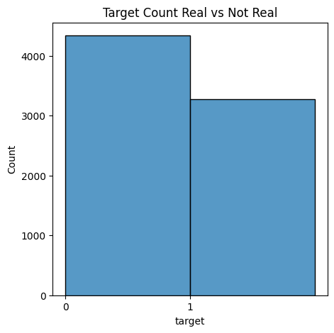

```
Imbalance:  1.3522595596755504

Where are tweets from?
location
USA                104
New York            71
United States       50
London              45
Canada              29
Nigeria             28
UK                  27
Los Angeles, CA     26
India               24
Mumbai              22
Name: count, dtype: int64
```

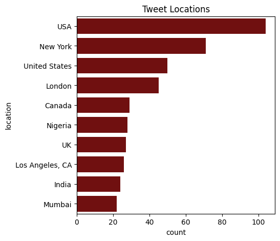

```
Train Shape X/Y:
(6090,)
(6090,)
Validation Shape X/Y:
(1523,)
(1523,)
```

```python
text_lengths_1 = []
text_lengths_0 = []

####
#### This code plots text length distribution for disaster and non-disaster tweets
####
for index,row in df_train.iterrows():
    if row['target']==1:
        text_lengths_1.append(len(row['text']))

    if row['target']==0:
        text_lengths_0.append(len(row['text']))

sns.histplot(text_lengths_0, label='Not Disaster')
sns.histplot(text_lengths_1, label='Disaster')
plt.title("Train Data - Text Lengths Distribution")
plt.xlabel('Text Length')
plt.legend(loc='upper left')
plt.show()

print("Examples of Disaster Tweets")
print(df_train[df_train['target']==1]['text'][0:10])

print("\nExamples of Non-Disaster Tweets")
print(df_train[df_train['target']==0]['text'][0:10])

####
## Clean data- looking for null values for text column
####
print("train dimensions: ", df_train.shape)
print("test dimensions: ", df_test.shape)

#Checking for null values and duplicates
print("\nTrain Dataset")
print("\nNull values in text?: ",df_train['text'].isnull().values.sum())
print("\nNull values in keyword?: ",df_train['keyword'].isnull().values.sum())
print("\nNull values in location?: ",df_train['location'].isnull().values.sum())
print("\n\nTest Dataset")
print("\nNull values in text?: ",df_test['text'].isnull().values.sum())
print("\nNull values in keyword?: ",df_test['keyword'].isnull().values.sum())
print("\nNull values in location?: ",df_test['location'].isnull().values.sum())


#####
# counts plot by target
####
print()
plt.figure(figsize = (5,5))
sns.histplot(df_train['target'],bins=range(3), ec='k')
plt.xticks([0,1])
plt.title("Target Count Real vs Not Real")
plt.show()

####
#calculate imbalance ratio
####
num_zeros = (y_train== 0).sum()
num_ones = (y_train == 1).sum()
imbalance = num_zeros/num_ones
print("Imbalance: ", imbalance)


#####
# counts plot by location
#####
print("\nWhere are tweets from?")
print(df_train['location'].value_counts()[:10])
plt.figure(figsize = (5,5))
sns.barplot(y=df_train['location'].value_counts()[:10].index,x=df_train['location'].value_counts()[:10], color='maroon')
plt.title("Tweet Locations")
plt.show()


###
## Split into train file into train and validation datasets
###

target = df_train["target"]
x = df_train.drop(["id","location", "target"], axis=1)
X_train, X_test, y_train, y_test = train_test_split(df_train["text"], target, test_size=0.2, random_state=1234)

print("Train Shape X/Y: ")
print(X_train.shape)
print(y_train.shape)
print("Validation Shape X/Y: ")
print(X_test.shape)
print(y_test.shape)
```

### Models

The first step in creating the model was to process the text. I used the Keras Tokenizer API which converts all characters to lowercase, it removes unnecessay characters such as symbols, puncuation, and numbers. It converts the text into a list of words in a string. I create a word embedding using GloVE (Global Vectors for Word Representation) for the model. This converts the sequence of words into a vectorized form. This vector format captures semantic relationships between words.

Since sequence in text is important, I use an Recurrent Neural Network model with LSTM (Long Short Term Memory). I use the embedding from GloVE in the input layer to transform the input sequences into a vector of size 100. I then use a bi-directional LSTM layer followed by a dense layer with an relu activation function. I use a drop out laye for regulation and then a final dense layer with a sigmoid activation function for the output label classification.

```python
# Text Prepocessing
# This code performs tokenization of the tweet text
tokenizer = Tokenizer()  # # create the tokenizer
tokenizer.fit_on_texts(X_train)
tokenizer.fit_on_texts(X_test)


X_train_seq = tokenizer.texts_to_sequences(X_train)
X_test_seq = tokenizer.texts_to_sequences(X_test)
x_sub_test = tokenizer.texts_to_sequences(df_test["text"])
# Pad sequences to a fixed length
X_train_seq = pad_sequences(X_train_seq,truncating='post', padding='post')
X_test_seq = pad_sequences(X_test_seq,truncating='post', padding='post')
x_sub_test = pad_sequences(x_sub_test,truncating='post', padding='post')
X_train_seq.shape
```

```
(6090, 33)
```

```python
### Embedding Function Using Glove 6B 100 text file

def embedding_for_vocab(filepath, word_index,
                        embedding_dim):
    vocab_size = len(word_index) + 1


    embedding_matrix_vocab = np.zeros((vocab_size,
                                       embedding_dim))

    with open(filepath, encoding="utf8") as f:
        for line in f:
            word, *vector = line.split()
            if word in word_index:
                idx = word_index[word]
                embedding_matrix_vocab[idx] = np.array(
                    vector, dtype=np.float32)[:embedding_dim]

    return embedding_matrix_vocab


embedding_matrix_vocab = embedding_for_vocab(
    'glove.6B.100d.txt', tokenizer.word_index,
  100)
```

```python
#####
# This code builds the RNN model
#####
opt = optimizers.Adam(learning_rate=0.01, beta_1=0.9)

model = Sequential()
model.add(Embedding(input_dim=embedding_matrix_vocab.shape[0],
                    output_dim=embedding_matrix_vocab.shape[1],
                    weights=[embedding_matrix_vocab],
                    input_length=30,
                    trainable=False))
model.add(Bidirectional(LSTM(64,recurrent_dropout=0.2)))
model.add(Dropout(0.2))
model.add(Dense(64, activation = "relu"))
model.add(Dropout(0.2))
model.add(Dense(1, activation='sigmoid'))


model.compile(optimizer=opt,loss='binary_crossentropy',metrics=['accuracy'])
```

### Results and Analysis

I run an initial model and plot the accuracy of the training data compared to the validation data. The accuracy of the training set is pretty decent- 0.98 at the 10th epoch. However the validation accuracy is only 0.80 which suggests there is overfitting in the model. The F1 score was 0.77. I perform some hyperparameter tuning to get this a little higher.

```
191/191 ━━━━━━━━━━━━━━━━━━━━ 3s 15ms/step - accuracy: 0.9845 - loss: 0.0296 - val_accuracy: 0.8063 - val_loss: 2.2264
191/191 ━━━━━━━━━━━━━━━━━━━━ 3s 15ms/step - accuracy: 0.9838 - loss: 0.0302 - val_accuracy: 0.8070 - val_loss: 2.1891
191/191 ━━━━━━━━━━━━━━━━━━━━ 3s 15ms/step - accuracy: 0.9849 - loss: 0.0302 - val_accuracy: 0.8024 - val_loss: 2.2214
191/191 ━━━━━━━━━━━━━━━━━━━━ 3s 15ms/step - accuracy: 0.9817 - loss: 0.0310 - val_accuracy: 0.8050 - val_loss: 2.2162
191/191 ━━━━━━━━━━━━━━━━━━━━ 3s 15ms/step - accuracy: 0.9856 - loss: 0.0390 - val_accuracy: 0.8043 - val_loss: 2.1365
191/191 ━━━━━━━━━━━━━━━━━━━━ 3s 15ms/step - accuracy: 0.9825 - loss: 0.0315 - val_accuracy: 0.8089 - val_loss: 2.1296
191/191 ━━━━━━━━━━━━━━━━━━━━ 3s 15ms/step - accuracy: 0.9837 - loss: 0.0323 - val_accuracy: 0.8083 - val_loss: 2.1701
191/191 ━━━━━━━━━━━━━━━━━━━━ 3s 15ms/step - accuracy: 0.9846 - loss: 0.0291 - val_accuracy: 0.8050 - val_loss: 2.2688
191/191 ━━━━━━━━━━━━━━━━━━━━ 3s 15ms/step - accuracy: 0.9825 - loss: 0.0339 - val_accuracy: 0.8030 - val_loss: 2.2499
191/191 ━━━━━━━━━━━━━━━━━━━━ 3s 15ms/step - accuracy: 0.9839 - loss: 0.0314 - val_accuracy: 0.8017 - val_loss: 2.1582
```

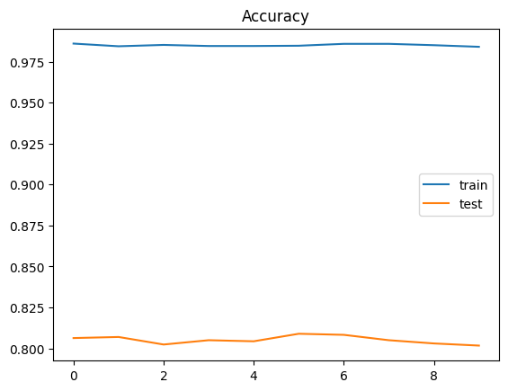

```
48/48 ━━━━━━━━━━━━━━━━━━━━ 0s 4ms/step
F1 Score:  0.770516717325228
```

```python
####
# Train the model
###
lstm_model = model.fit(X_train_seq, y_train, epochs=10, batch_size=32, validation_data = (X_test_seq, y_test))

plt.title('Accuracy')
plt.plot(lstm_model.history['accuracy'], label='train')
plt.plot(lstm_model.history['val_accuracy'], label='test')
plt.legend()
plt.show();

#predictions and f1 score
y_pred =np.round(model.predict(X_test_seq))

print("F1 Score: ",f1_score(y_test, y_pred))
```

Hyperparameter Tuning

I tried different approaches to tuning the hyperparameters. I tried lowering the learning rate, changing the optimizer to RMS Prop, increasing batch size and epoch number. Finally I did I combination of increased epochs and decreased learning rate. The results are summarized in a table below.

```
191/191 ━━━━━━━━━━━━━━━━━━━━ 4s 12ms/step - accuracy: 0.9840 - loss: 0.0434 - val_accuracy: 0.7932 - val_loss: 1.8165
191/191 ━━━━━━━━━━━━━━━━━━━━ 3s 14ms/step - accuracy: 0.9783 - loss: 0.0570 - val_accuracy: 0.8043 - val_loss: 1.8758
191/191 ━━━━━━━━━━━━━━━━━━━━ 3s 15ms/step - accuracy: 0.9795 - loss: 0.0539 - val_accuracy: 0.8011 - val_loss: 1.7285
191/191 ━━━━━━━━━━━━━━━━━━━━ 3s 15ms/step - accuracy: 0.9736 - loss: 0.0723 - val_accuracy: 0.8063 - val_loss: 1.4450
191/191 ━━━━━━━━━━━━━━━━━━━━ 3s 15ms/step - accuracy: 0.9790 - loss: 0.0513 - val_accuracy: 0.7958 - val_loss: 1.3402
191/191 ━━━━━━━━━━━━━━━━━━━━ 3s 15ms/step - accuracy: 0.9769 - loss: 0.0533 - val_accuracy: 0.8037 - val_loss: 1.3474
191/191 ━━━━━━━━━━━━━━━━━━━━ 3s 15ms/step - accuracy: 0.9741 - loss: 0.0596 - val_accuracy: 0.8011 - val_loss: 1.3721
191/191 ━━━━━━━━━━━━━━━━━━━━ 3s 15ms/step - accuracy: 0.9800 - loss: 0.0502 - val_accuracy: 0.7971 - val_loss: 1.1951
191/191 ━━━━━━━━━━━━━━━━━━━━ 3s 15ms/step - accuracy: 0.9786 - loss: 0.0459 - val_accuracy: 0.7912 - val_loss: 1.5901
191/191 ━━━━━━━━━━━━━━━━━━━━ 3s 15ms/step - accuracy: 0.9765 - loss: 0.0531 - val_accuracy: 0.7945 - val_loss: 1.5667
```

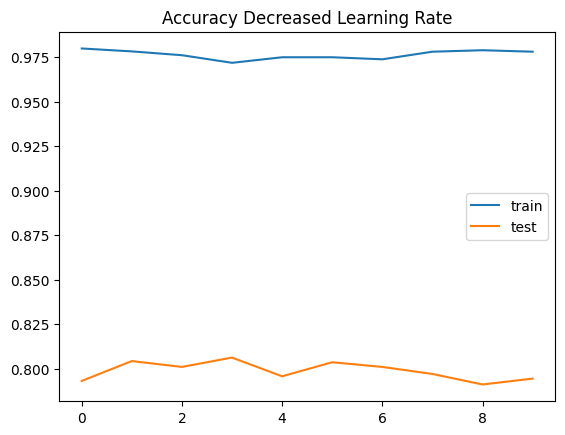

```
48/48 ━━━━━━━━━━━━━━━━━━━━ 0s 5ms/step
F1 Score Decreased Learning Rate:  0.7658937920718025
191/191 ━━━━━━━━━━━━━━━━━━━━ 3s 12ms/step - accuracy: 0.9774 - loss: 0.0494 - val_accuracy: 0.8004 - val_loss: 1.6714
191/191 ━━━━━━━━━━━━━━━━━━━━ 3s 14ms/step - accuracy: 0.9848 - loss: 0.0350 - val_accuracy: 0.8011 - val_loss: 1.7988
191/191 ━━━━━━━━━━━━━━━━━━━━ 3s 15ms/step - accuracy: 0.9829 - loss: 0.0389 - val_accuracy: 0.7997 - val_loss: 1.9420
191/191 ━━━━━━━━━━━━━━━━━━━━ 3s 15ms/step - accuracy: 0.9831 - loss: 0.0393 - val_accuracy: 0.7991 - val_loss: 1.9633
191/191 ━━━━━━━━━━━━━━━━━━━━ 3s 15ms/step - accuracy: 0.9840 - loss: 0.0378 - val_accuracy: 0.8004 - val_loss: 1.9944
191/191 ━━━━━━━━━━━━━━━━━━━━ 3s 15ms/step - accuracy: 0.9827 - loss: 0.0383 - val_accuracy: 0.7978 - val_loss: 2.0073
191/191 ━━━━━━━━━━━━━━━━━━━━ 3s 15ms/step - accuracy: 0.9824 - loss: 0.0375 - val_accuracy: 0.7958 - val_loss: 1.9941
191/191 ━━━━━━━━━━━━━━━━━━━━ 3s 14ms/step - accuracy: 0.9833 - loss: 0.0363 - val_accuracy: 0.7984 - val_loss: 2.0600
191/191 ━━━━━━━━━━━━━━━━━━━━ 3s 15ms/step - accuracy: 0.9822 - loss: 0.0383 - val_accuracy: 0.7997 - val_loss: 2.0870
191/191 ━━━━━━━━━━━━━━━━━━━━ 3s 15ms/step - accuracy: 0.9834 - loss: 0.0355 - val_accuracy: 0.7991 - val_loss: 2.1883
```

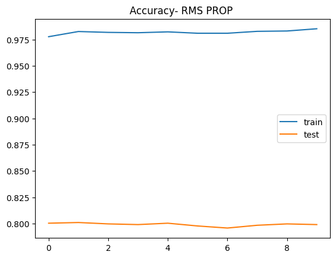

```
48/48 ━━━━━━━━━━━━━━━━━━━━ 0s 5ms/step
F1 Score RMSProp Optimizer:  0.7649769585253456
96/96 ━━━━━━━━━━━━━━━━━━━━ 3s 16ms/step - accuracy: 0.9856 - loss: 0.0307 - val_accuracy: 0.7978 - val_loss: 2.2161
96/96 ━━━━━━━━━━━━━━━━━━━━ 2s 24ms/step - accuracy: 0.9834 - loss: 0.0395 - val_accuracy: 0.7984 - val_loss: 2.1742
96/96 ━━━━━━━━━━━━━━━━━━━━ 2s 24ms/step - accuracy: 0.9871 - loss: 0.0316 - val_accuracy: 0.7991 - val_loss: 2.1967
96/96 ━━━━━━━━━━━━━━━━━━━━ 2s 24ms/step - accuracy: 0.9822 - loss: 0.0352 - val_accuracy: 0.7971 - val_loss: 2.2207
96/96 ━━━━━━━━━━━━━━━━━━━━ 2s 24ms/step - accuracy: 0.9852 - loss: 0.0344 - val_accuracy: 0.7951 - val_loss: 2.1893
96/96 ━━━━━━━━━━━━━━━━━━━━ 2s 25ms/step - accuracy: 0.9843 - loss: 0.0319 - val_accuracy: 0.7971 - val_loss: 2.2188
96/96 ━━━━━━━━━━━━━━━━━━━━ 2s 25ms/step - accuracy: 0.9865 - loss: 0.0368 - val_accuracy: 0.7984 - val_loss: 2.2432
96/96 ━━━━━━━━━━━━━━━━━━━━ 2s 25ms/step - accuracy: 0.9861 - loss: 0.0307 - val_accuracy: 0.7997 - val_loss: 2.2656
96/96 ━━━━━━━━━━━━━━━━━━━━ 2s 25ms/step - accuracy: 0.9833 - loss: 0.0356 - val_accuracy: 0.8011 - val_loss: 2.2200
96/96 ━━━━━━━━━━━━━━━━━━━━ 2s 25ms/step - accuracy: 0.9821 - loss: 0.0375 - val_accuracy: 0.7971 - val_loss: 2.2704
```

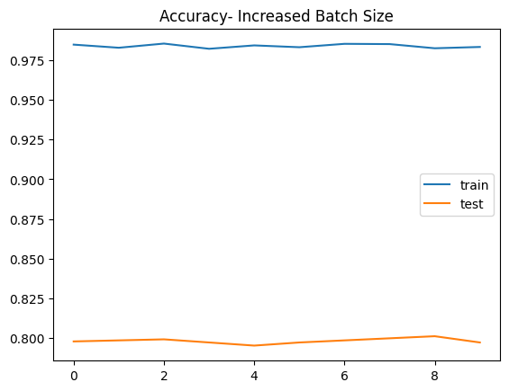

```
48/48 ━━━━━━━━━━━━━━━━━━━━ 0s 5ms/step
F1 Score Increased Batch Size:  0.7621247113163973
191/191 ━━━━━━━━━━━━━━━━━━━━ 5s 12ms/step - accuracy: 0.9835 - loss: 0.0317 - val_accuracy: 0.7991 - val_loss: 2.3515
191/191 ━━━━━━━━━━━━━━━━━━━━ 3s 14ms/step - accuracy: 0.9826 - loss: 0.0324 - val_accuracy: 0.8004 - val_loss: 2.4363
191/191 ━━━━━━━━━━━━━━━━━━━━ 3s 15ms/step - accuracy: 0.9843 - loss: 0.0353 - val_accuracy: 0.7984 - val_loss: 2.4105
191/191 ━━━━━━━━━━━━━━━━━━━━ 3s 15ms/step - accuracy: 0.9859 - loss: 0.0294 - val_accuracy: 0.7997 - val_loss: 2.5282
191/191 ━━━━━━━━━━━━━━━━━━━━ 3s 15ms/step - accuracy: 0.9840 - loss: 0.0406 - val_accuracy: 0.7991 - val_loss: 2.4813
191/191 ━━━━━━━━━━━━━━━━━━━━ 3s 15ms/step - accuracy: 0.9853 - loss: 0.0367 - val_accuracy: 0.7997 - val_loss: 2.4904
191/191 ━━━━━━━━━━━━━━━━━━━━ 3s 15ms/step - accuracy: 0.9820 - loss: 0.0450 - val_accuracy: 0.7971 - val_loss: 2.5011
191/191 ━━━━━━━━━━━━━━━━━━━━ 3s 15ms/step - accuracy: 0.9832 - loss: 0.0371 - val_accuracy: 0.7991 - val_loss: 2.5134
191/191 ━━━━━━━━━━━━━━━━━━━━ 3s 15ms/step - accuracy: 0.9840 - loss: 0.0325 - val_accuracy: 0.7984 - val_loss: 2.6135
191/191 ━━━━━━━━━━━━━━━━━━━━ 3s 15ms/step - accuracy: 0.9856 - loss: 0.0277 - val_accuracy: 0.8004 - val_loss: 2.7104
191/191 ━━━━━━━━━━━━━━━━━━━━ 3s 15ms/step - accuracy: 0.9855 - loss: 0.0336 - val_accuracy: 0.7978 - val_loss: 2.8001
191/191 ━━━━━━━━━━━━━━━━━━━━ 3s 15ms/step - accuracy: 0.9818 - loss: 0.0352 - val_accuracy: 0.7984 - val_loss: 2.7301
191/191 ━━━━━━━━━━━━━━━━━━━━ 3s 15ms/step - accuracy: 0.9826 - loss: 0.0361 - val_accuracy: 0.8017 - val_loss: 2.6874
191/191 ━━━━━━━━━━━━━━━━━━━━ 3s 15ms/step - accuracy: 0.9851 - loss: 0.0315 - val_accuracy: 0.8004 - val_loss: 2.6988
191/191 ━━━━━━━━━━━━━━━━━━━━ 3s 15ms/step - accuracy: 0.9847 - loss: 0.0276 - val_accuracy: 0.8017 - val_loss: 2.7968
191/191 ━━━━━━━━━━━━━━━━━━━━ 3s 15ms/step - accuracy: 0.9805 - loss: 0.0377 - val_accuracy: 0.8050 - val_loss: 2.7952
191/191 ━━━━━━━━━━━━━━━━━━━━ 3s 15ms/step - accuracy: 0.9873 - loss: 0.0314 - val_accuracy: 0.8056 - val_loss: 2.7331
191/191 ━━━━━━━━━━━━━━━━━━━━ 3s 15ms/step - accuracy: 0.9854 - loss: 0.0347 - val_accuracy: 0.8030 - val_loss: 2.8794
191/191 ━━━━━━━━━━━━━━━━━━━━ 3s 15ms/step - accuracy: 0.9844 - loss: 0.0358 - val_accuracy: 0.8017 - val_loss: 2.9339
191/191 ━━━━━━━━━━━━━━━━━━━━ 3s 15ms/step - accuracy: 0.9864 - loss: 0.0296 - val_accuracy: 0.7997 - val_loss: 3.0109
```

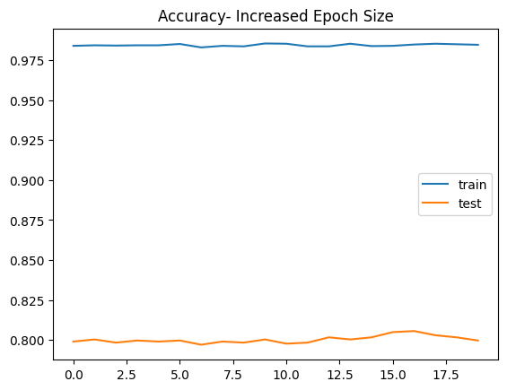

```
48/48 ━━━━━━━━━━━━━━━━━━━━ 0s 5ms/step
F1 Score Increased Epoch Number:  0.765564950038432
```

```python
####
# Hyperparameter Tuning -
###

#  Decrease Learning Rate by half
opt = optimizers.Adam(learning_rate=0.005, beta_1=0.9)
model.compile(optimizer=opt,loss='binary_crossentropy',metrics=['accuracy'])

lstm_model_2 = model.fit(X_train_seq, y_train, epochs=10, batch_size=32, validation_data = (X_test_seq, y_test))


plt.title('Accuracy Decreased Learning Rate')
plt.plot(lstm_model_2.history['accuracy'], label='train')
plt.plot(lstm_model_2.history['val_accuracy'], label='test')
plt.legend()
plt.show();

#predictions and f1 score
y_pred =np.round(model.predict(X_test_seq))
print("F1 Score Decreased Learning Rate: ",f1_score(y_test, y_pred))



# Change Optimizer from ADAM to RMS Prop

#opt = optimizers.RMSPROP(learning_rate=0.01)
model.compile(optimizer='rmsprop',loss='binary_crossentropy',metrics=['accuracy'])

lstm_model_3 = model.fit(X_train_seq, y_train, epochs=10, batch_size=32, validation_data = (X_test_seq, y_test))

plt.title('Accuracy- RMS PROP ')
plt.plot(lstm_model_3.history['accuracy'], label='train')
plt.plot(lstm_model_3.history['val_accuracy'], label='test')
plt.legend()
plt.show();

#predictions and f1 score
y_pred =np.round(model.predict(X_test_seq))
print("F1 Score RMSProp Optimizer: ",f1_score(y_test, y_pred))


# Change Batch Size from 32 to 64

opt = optimizers.Adam(learning_rate=0.01, beta_1=0.9)
model.compile(optimizer='rmsprop',loss='binary_crossentropy',metrics=['accuracy'])

lstm_model_4 = model.fit(X_train_seq, y_train, epochs=10, batch_size=64, validation_data = (X_test_seq, y_test))

plt.title('Accuracy- Increased Batch Size')
plt.plot(lstm_model_4.history['accuracy'], label='train')
plt.plot(lstm_model_4.history['val_accuracy'], label='test')
plt.legend()
plt.show();

#predictions and f1 score
y_pred =np.round(model.predict(X_test_seq))
print("F1 Score Increased Batch Size: ",f1_score(y_test, y_pred))


# Increase Epoch
opt = optimizers.Adam(learning_rate=0.01, beta_1=0.9)
model.compile(optimizer='rmsprop',loss='binary_crossentropy',metrics=['accuracy'])

lstm_model_5 = model.fit(X_train_seq, y_train, epochs=20, batch_size=32, validation_data = (X_test_seq, y_test))

plt.title('Accuracy- Increased Epoch Size')
plt.plot(lstm_model_5.history['accuracy'], label='train')
plt.plot(lstm_model_5.history['val_accuracy'], label='test')
plt.legend()
plt.show();

#predictions and f1 score
y_pred =np.round(model.predict(X_test_seq))
print("F1 Score Increased Epoch Number: ",f1_score(y_test, y_pred))
```

```
191/191 ━━━━━━━━━━━━━━━━━━━━ 4s 12ms/step - accuracy: 0.9824 - loss: 0.0326 - val_accuracy: 0.8024 - val_loss: 2.3037
191/191 ━━━━━━━━━━━━━━━━━━━━ 3s 14ms/step - accuracy: 0.9833 - loss: 0.0333 - val_accuracy: 0.7991 - val_loss: 2.1897
191/191 ━━━━━━━━━━━━━━━━━━━━ 3s 15ms/step - accuracy: 0.9847 - loss: 0.0326 - val_accuracy: 0.8017 - val_loss: 2.1412
191/191 ━━━━━━━━━━━━━━━━━━━━ 3s 15ms/step - accuracy: 0.9842 - loss: 0.0346 - val_accuracy: 0.8011 - val_loss: 2.1349
191/191 ━━━━━━━━━━━━━━━━━━━━ 3s 15ms/step - accuracy: 0.9851 - loss: 0.0311 - val_accuracy: 0.8043 - val_loss: 2.1277
191/191 ━━━━━━━━━━━━━━━━━━━━ 3s 15ms/step - accuracy: 0.9823 - loss: 0.0334 - val_accuracy: 0.8004 - val_loss: 2.1378
191/191 ━━━━━━━━━━━━━━━━━━━━ 3s 15ms/step - accuracy: 0.9860 - loss: 0.0326 - val_accuracy: 0.8024 - val_loss: 2.1487
191/191 ━━━━━━━━━━━━━━━━━━━━ 3s 15ms/step - accuracy: 0.9849 - loss: 0.0362 - val_accuracy: 0.8011 - val_loss: 2.1865
191/191 ━━━━━━━━━━━━━━━━━━━━ 3s 15ms/step - accuracy: 0.9841 - loss: 0.0360 - val_accuracy: 0.7984 - val_loss: 2.1513
191/191 ━━━━━━━━━━━━━━━━━━━━ 3s 15ms/step - accuracy: 0.9850 - loss: 0.0328 - val_accuracy: 0.7978 - val_loss: 2.2755
191/191 ━━━━━━━━━━━━━━━━━━━━ 3s 15ms/step - accuracy: 0.9844 - loss: 0.0332 - val_accuracy: 0.8011 - val_loss: 2.2613
191/191 ━━━━━━━━━━━━━━━━━━━━ 3s 15ms/step - accuracy: 0.9828 - loss: 0.0366 - val_accuracy: 0.8004 - val_loss: 2.2819
191/191 ━━━━━━━━━━━━━━━━━━━━ 3s 15ms/step - accuracy: 0.9858 - loss: 0.0339 - val_accuracy: 0.8004 - val_loss: 2.2583
191/191 ━━━━━━━━━━━━━━━━━━━━ 3s 15ms/step - accuracy: 0.9817 - loss: 0.0353 - val_accuracy: 0.7965 - val_loss: 2.1566
191/191 ━━━━━━━━━━━━━━━━━━━━ 3s 15ms/step - accuracy: 0.9839 - loss: 0.0350 - val_accuracy: 0.8004 - val_loss: 2.2722
191/191 ━━━━━━━━━━━━━━━━━━━━ 3s 15ms/step - accuracy: 0.9850 - loss: 0.0309 - val_accuracy: 0.7919 - val_loss: 2.3638
191/191 ━━━━━━━━━━━━━━━━━━━━ 3s 15ms/step - accuracy: 0.9874 - loss: 0.0307 - val_accuracy: 0.7965 - val_loss: 2.2539
191/191 ━━━━━━━━━━━━━━━━━━━━ 3s 15ms/step - accuracy: 0.9843 - loss: 0.0321 - val_accuracy: 0.7991 - val_loss: 2.1848
191/191 ━━━━━━━━━━━━━━━━━━━━ 3s 15ms/step - accuracy: 0.9869 - loss: 0.0292 - val_accuracy: 0.7919 - val_loss: 2.0238
191/191 ━━━━━━━━━━━━━━━━━━━━ 3s 15ms/step - accuracy: 0.9862 - loss: 0.0365 - val_accuracy: 0.7997 - val_loss: 2.1166
191/191 ━━━━━━━━━━━━━━━━━━━━ 3s 15ms/step - accuracy: 0.9828 - loss: 0.0323 - val_accuracy: 0.8024 - val_loss: 2.0643
191/191 ━━━━━━━━━━━━━━━━━━━━ 3s 15ms/step - accuracy: 0.9852 - loss: 0.0320 - val_accuracy: 0.7945 - val_loss: 2.1305
191/191 ━━━━━━━━━━━━━━━━━━━━ 3s 15ms/step - accuracy: 0.9855 - loss: 0.0346 - val_accuracy: 0.8011 - val_loss: 2.2196
191/191 ━━━━━━━━━━━━━━━━━━━━ 3s 15ms/step - accuracy: 0.9853 - loss: 0.0305 - val_accuracy: 0.8004 - val_loss: 2.2288
191/191 ━━━━━━━━━━━━━━━━━━━━ 3s 15ms/step - accuracy: 0.9809 - loss: 0.0421 - val_accuracy: 0.7971 - val_loss: 2.1823
191/191 ━━━━━━━━━━━━━━━━━━━━ 3s 15ms/step - accuracy: 0.9873 - loss: 0.0291 - val_accuracy: 0.8030 - val_loss: 2.2199
191/191 ━━━━━━━━━━━━━━━━━━━━ 3s 15ms/step - accuracy: 0.9859 - loss: 0.0310 - val_accuracy: 0.8063 - val_loss: 2.2261
191/191 ━━━━━━━━━━━━━━━━━━━━ 3s 15ms/step - accuracy: 0.9856 - loss: 0.0277 - val_accuracy: 0.8017 - val_loss: 2.2722
191/191 ━━━━━━━━━━━━━━━━━━━━ 3s 15ms/step - accuracy: 0.9844 - loss: 0.0294 - val_accuracy: 0.8024 - val_loss: 2.3347
191/191 ━━━━━━━━━━━━━━━━━━━━ 3s 15ms/step - accuracy: 0.9838 - loss: 0.0353 - val_accuracy: 0.8070 - val_loss: 2.1659
191/191 ━━━━━━━━━━━━━━━━━━━━ 3s 15ms/step - accuracy: 0.9866 - loss: 0.0295 - val_accuracy: 0.8076 - val_loss: 2.2348
191/191 ━━━━━━━━━━━━━━━━━━━━ 3s 15ms/step - accuracy: 0.9863 - loss: 0.0294 - val_accuracy: 0.8096 - val_loss: 2.1884
191/191 ━━━━━━━━━━━━━━━━━━━━ 3s 15ms/step - accuracy: 0.9847 - loss: 0.0322 - val_accuracy: 0.8089 - val_loss: 2.2392
191/191 ━━━━━━━━━━━━━━━━━━━━ 3s 15ms/step - accuracy: 0.9846 - loss: 0.0307 - val_accuracy: 0.8102 - val_loss: 2.2712
191/191 ━━━━━━━━━━━━━━━━━━━━ 3s 15ms/step - accuracy: 0.9862 - loss: 0.0271 - val_accuracy: 0.8089 - val_loss: 2.1921
191/191 ━━━━━━━━━━━━━━━━━━━━ 3s 15ms/step - accuracy: 0.9813 - loss: 0.0351 - val_accuracy: 0.8050 - val_loss: 2.1654
191/191 ━━━━━━━━━━━━━━━━━━━━ 3s 15ms/step - accuracy: 0.9862 - loss: 0.0312 - val_accuracy: 0.8070 - val_loss: 2.1702
191/191 ━━━━━━━━━━━━━━━━━━━━ 3s 15ms/step - accuracy: 0.9837 - loss: 0.0312 - val_accuracy: 0.8056 - val_loss: 2.1213
191/191 ━━━━━━━━━━━━━━━━━━━━ 3s 15ms/step - accuracy: 0.9860 - loss: 0.0293 - val_accuracy: 0.8076 - val_loss: 2.2364
191/191 ━━━━━━━━━━━━━━━━━━━━ 3s 15ms/step - accuracy: 0.9842 - loss: 0.0293 - val_accuracy: 0.8050 - val_loss: 2.1667
191/191 ━━━━━━━━━━━━━━━━━━━━ 3s 15ms/step - accuracy: 0.9847 - loss: 0.0329 - val_accuracy: 0.8043 - val_loss: 2.2310
191/191 ━━━━━━━━━━━━━━━━━━━━ 3s 15ms/step - accuracy: 0.9867 - loss: 0.0296 - val_accuracy: 0.8030 - val_loss: 2.3100
191/191 ━━━━━━━━━━━━━━━━━━━━ 3s 15ms/step - accuracy: 0.9845 - loss: 0.0443 - val_accuracy: 0.8076 - val_loss: 2.1636
191/191 ━━━━━━━━━━━━━━━━━━━━ 3s 15ms/step - accuracy: 0.9852 - loss: 0.0308 - val_accuracy: 0.8063 - val_loss: 2.1197
191/191 ━━━━━━━━━━━━━━━━━━━━ 3s 15ms/step - accuracy: 0.9846 - loss: 0.0313 - val_accuracy: 0.8037 - val_loss: 2.1498
191/191 ━━━━━━━━━━━━━━━━━━━━ 3s 15ms/step - accuracy: 0.9836 - loss: 0.0356 - val_accuracy: 0.8050 - val_loss: 2.1191
191/191 ━━━━━━━━━━━━━━━━━━━━ 3s 15ms/step - accuracy: 0.9852 - loss: 0.0348 - val_accuracy: 0.8056 - val_loss: 2.1753
191/191 ━━━━━━━━━━━━━━━━━━━━ 3s 15ms/step - accuracy: 0.9826 - loss: 0.0311 - val_accuracy: 0.8050 - val_loss: 2.2017
191/191 ━━━━━━━━━━━━━━━━━━━━ 3s 15ms/step - accuracy: 0.9853 - loss: 0.0304 - val_accuracy: 0.8043 - val_loss: 2.1776
191/191 ━━━━━━━━━━━━━━━━━━━━ 3s 15ms/step - accuracy: 0.9841 - loss: 0.0295 - val_accuracy: 0.8037 - val_loss: 2.1894
```

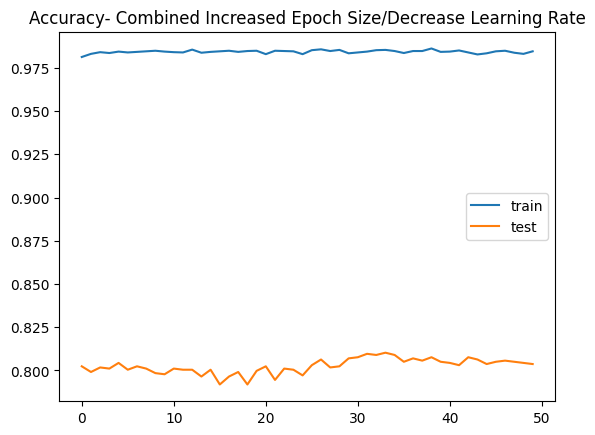

```
48/48 ━━━━━━━━━━━━━━━━━━━━ 0s 5ms/step
F1 Score Combined Increased Epoch Size/Decrease Learning Rate:  0.7722772277227723
```

```python
#Decrease Learning Increase Epoch
opt = optimizers.Adam(learning_rate=0.001, beta_1=0.9)
model.compile(optimizer=opt,loss='binary_crossentropy',metrics=['accuracy'])

lstm_model_6 = model.fit(X_train_seq, y_train, epochs=50, batch_size=32, validation_data = (X_test_seq, y_test))

plt.title('Accuracy- Combined Increased Epoch Size/Decrease Learning Rate')
plt.plot(lstm_model_6.history['accuracy'], label='train')
plt.plot(lstm_model_6.history['val_accuracy'], label='test')
plt.legend()
plt.show();

#predictions and f1 score
y_pred =np.round(model.predict(X_test_seq))
print("F1 Score Combined Increased Epoch Size/Decrease Learning Rate: ",f1_score(y_test, y_pred))
```

**Hyperparameter Tuning Results**

The table below shows the performance metrics for the different hyperparameter tuning strategies. These hyperparameter modifications did not appear to have a significant outcome on the accuracy or f1 score of the validation data. The accuracy of the training set is very good and the validation accuracy and f1 of 0.8 and 0.77 respectively are not too bad, but the differences suggest there is still inherent overfitting in the model.

[output not shown]

[output not shown]

### Conclusion

This project provided a good exercise in NLP (Natural Language Processing) and also showed the potential in creating RNN/LSTM models. The model I created was able to classify whether a twitter tweet was about an actual disaster with approximately 80 percent accuracy. In this project I experimented with tuning hyperparameters to get an even better accuracy, however these results did not lead to too much improvement. For future modifications in attempting to achieve higher accuracy, making changes to the model's architecture such as adding additional layers may be needed. Making modifications to the text processing could also be an improvement to explore in the future.

### References

Andreshg. (2021, May 10). NLP 📝 GloVe, BERT, TF-IDF, LSTM... 📝 Explained. Kaggle.com; Kaggle. https://www.kaggle.com/code/andreshg/nlp-glove-bert-tf-idf-lstm-explained

Feldges, C. (2022, April 2). Text Classification with TF-IDF, LSTM, BERT: a quantitative comparison. Medium. https://medium.com/@claude.feldges/text-classification-with-tf-idf-lstm-bert-a-quantitative-comparison-b8409b556cb3

Kumar, V. (2020, February 23). Real or Not? NLP with Disaster Tweets (A Data science Capstone Project). Medium; Real or Not? NLP with Disaster Tweets. https://medium.com/real-or-not-nlp-with-disaster-tweets/real-or-not-nlp-with-disaster-tweets-a-data-science-capstone-project-fafa6c35c16f

```python
###
# Kaggle Submission Code - score 0.779
###
y_pred = model.predict(x_sub_test)
y_pred =np.round(y_pred).astype(int).reshape(3263)
print(y_pred)

sub = pd.DataFrame(
    list(zip(df_test['id'], y_pred)),
    columns=["id", "target"],
)
print(sub)
sub.to_csv("submission.csv", index=False)
```

```
102/102 ━━━━━━━━━━━━━━━━━━━━ 0s 4ms/step
[0 1 0 ... 1 1 0]
         id  target
0         0       0
1         2       1
2         3       0
3         9       1
4        11       1
...     ...     ...
3258  10861       1
3259  10865       1
3260  10868       1
3261  10874       1
3262  10875       0

[3263 rows x 2 columns]
```